# GenomicRanges: Bioconductor Package for Genomic Data

# Part 1 — What are genomic ranges?

## What are genomic ranges?

A genomic range = an interval on a genome.

It is defined by:

- **seqname** — chromosome or contig (e.g. `"chr1"`)
- **start / end** — 1-based, end-inclusive
- **strand** — `+`, `-`, or `*`
- optional **metadata** — gene name, score, GC, …

Used for: genes, exons, peaks, variants, primer hits.

## Core classes in GenomicRanges

- **`GRanges`** — a vector of intervals (the workhorse).
- **`GRangesList`** — a list of GRanges (e.g., exons grouped by transcript).
- **`GPos`** — single-position version (rarely used here).

## Relationship with Biostrings

- `Biostrings` handles **sequence content** (DNAStringSet, …).
- `GenomicRanges` handles **coordinates**.
- Together: extract the DNA at an interval, count GC, scan for motifs.

# Part 2 — Plotting ranges

## Why plot ranges?

Range operations are easier to **see** than to read off a printed table.

Throughout this lesson we use a helper, `plotGenomicTracks()`, that wraps **Gviz** — Bioconductor’s track-plotting package. We will build on Gviz in later lessons, so it is worth meeting it here.

## The `plotGenomicTracks()` helper

```r
plotGenomicTracks <- function(tracks_list, colors = NULL,
                              chromosome = NULL,
                              from = NULL, to = NULL) {
  n <- length(tracks_list)
  if (is.null(colors)) colors <- rep("gray", n)
  annotation_tracks <- mapply(function(gr, col, nm) {
    args <- list(range = gr, name = nm, fill = col,
                 col = "black", stacking = "dense")
    if ("id" %in% names(mcols(gr))) {
      args$showFeatureId     <- TRUE
      args$featureAnnotation <- "id"
    }
    do.call(AnnotationTrack, args)
  }, gr = tracks_list, col = colors, nm = names(tracks_list),
     SIMPLIFY = FALSE)
  plotTracks(c(list(GenomeAxisTrack()), annotation_tracks),
             chromosome = chromosome, from = from, to = to,
             background.panel = "#FFFEDB", cex.title = 0.8)
}
```

Each named GRanges becomes one Gviz `AnnotationTrack`.

## How to call `plotGenomicTracks()`

- **Input** — a *named* list of `GRanges` objects.
  - Names → track titles (left side of plot).
- **Output** — a Gviz multi-track figure with a genome axis on top.
- Add an `id` metadata column to label individual intervals.

```r
plotGenomicTracks(list(gr1 = gr1, gr2 = gr2))
```

## Trying `plotGenomicTracks()`

```r
demo <- GRanges("chr1",
                IRanges(start = c(5, 30, 60), end = c(20, 45, 80)),
                strand = c("+", "-", "*"),
                id = c("a", "b", "c"))
plotGenomicTracks(list(demo = demo))
```

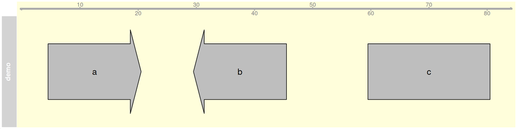

# Part 3 — Creating and inspecting GRanges

## Creating a GRanges object

```r
gr <- GRanges(
  seqnames = c("chr1", "chr2", "chr2", "chr1", "chr3"),
  ranges   = IRanges(start = c(10, 15, 20, 25, 30),
                     end   = c(20, 25, 30, 35, 40)),
  strand   = c("+", "-", "+", "*", "-"),
  score    = c(5, 10, 15, 20, 25),
  GC       = c(0.45, 0.55, 0.60, 0.70, 0.80)
)
gr
```

```
GRanges object with 5 ranges and 2 metadata columns:
      seqnames    ranges strand |     score        GC
         <Rle> <IRanges>  <Rle> | <numeric> <numeric>
  [1]     chr1     10-20      + |         5      0.45
  [2]     chr2     15-25      - |        10      0.55
  [3]     chr2     20-30      + |        15      0.60
  [4]     chr1     25-35      * |        20      0.70
  [5]     chr3     30-40      - |        25      0.80
  -------
  seqinfo: 3 sequences from an unspecified genome; no seqlengths
```

## Visualizing our GRanges

Gviz draws one chromosome at a time — show only the chr1 ranges.

```r
plotGenomicTracks(list(gr_chr1 = gr[seqnames(gr) == "chr1"]))
```

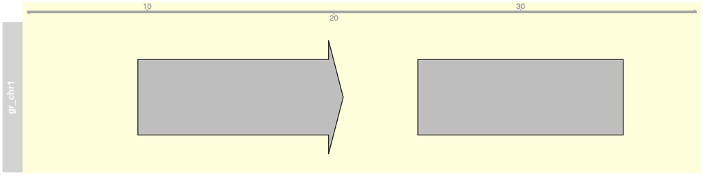

## Accessing GRanges components

```r
seqnames(gr)
```

```
factor-Rle of length 5 with 4 runs
  Lengths:    1    2    1    1
  Values : chr1 chr2 chr1 chr3
Levels(3): chr1 chr2 chr3
```

```r
strand(gr)
```

```
factor-Rle of length 5 with 5 runs
  Lengths: 1 1 1 1 1
  Values : + - + * -
Levels(3): + - *
```

```r
gr$score
```

```
[1]  5 10 15 20 25
```

```r
width(gr)
```

```
[1] 11 11 11 11 11
```

```r
length(gr)
```

```
[1] 5
```

> 📝 **Task 1** — create a GRanges of three intervals on `"chr1"` with strands of your choice and a metadata column `name`. Print and plot it.

# Part 4 — Subsetting GRanges

## Subsetting GRanges

```r
gr[1:3]                                          # by index
```

```
GRanges object with 3 ranges and 2 metadata columns:
      seqnames    ranges strand |     score        GC
         <Rle> <IRanges>  <Rle> | <numeric> <numeric>
  [1]     chr1     10-20      + |         5      0.45
  [2]     chr2     15-25      - |        10      0.55
  [3]     chr2     20-30      + |        15      0.60
  -------
  seqinfo: 3 sequences from an unspecified genome; no seqlengths
```

```r
gr[width(gr) > 10]                               # by width
```

```
GRanges object with 5 ranges and 2 metadata columns:
      seqnames    ranges strand |     score        GC
         <Rle> <IRanges>  <Rle> | <numeric> <numeric>
  [1]     chr1     10-20      + |         5      0.45
  [2]     chr2     15-25      - |        10      0.55
  [3]     chr2     20-30      + |        15      0.60
  [4]     chr1     25-35      * |        20      0.70
  [5]     chr3     30-40      - |        25      0.80
  -------
  seqinfo: 3 sequences from an unspecified genome; no seqlengths
```

```r
gr[seqnames(gr) == "chr1"]                       # by chromosome
```

```
GRanges object with 2 ranges and 2 metadata columns:
      seqnames    ranges strand |     score        GC
         <Rle> <IRanges>  <Rle> | <numeric> <numeric>
  [1]     chr1     10-20      + |         5      0.45
  [2]     chr1     25-35      * |        20      0.70
  -------
  seqinfo: 3 sequences from an unspecified genome; no seqlengths
```

## Subsetting GRanges

```r
gr[strand(gr) == "+"]                            # by strand
```

```
GRanges object with 2 ranges and 2 metadata columns:
      seqnames    ranges strand |     score        GC
         <Rle> <IRanges>  <Rle> | <numeric> <numeric>
  [1]     chr1     10-20      + |         5      0.45
  [2]     chr2     20-30      + |        15      0.60
  -------
  seqinfo: 3 sequences from an unspecified genome; no seqlengths
```

```r
gr[gr$score > 10]                                # by metadata
```

```
GRanges object with 3 ranges and 2 metadata columns:
      seqnames    ranges strand |     score        GC
         <Rle> <IRanges>  <Rle> | <numeric> <numeric>
  [1]     chr2     20-30      + |        15       0.6
  [2]     chr1     25-35      * |        20       0.7
  [3]     chr3     30-40      - |        25       0.8
  -------
  seqinfo: 3 sequences from an unspecified genome; no seqlengths
```

```r
gr[seqnames(gr) == "chr2" & strand(gr) == "+"]   # combined
```

```
GRanges object with 1 range and 2 metadata columns:
      seqnames    ranges strand |     score        GC
         <Rle> <IRanges>  <Rle> | <numeric> <numeric>
  [1]     chr2     20-30      + |        15       0.6
  -------
  seqinfo: 3 sequences from an unspecified genome; no seqlengths
```

> 📝 **Task 2** — from `gr`, keep only ranges on chr1 OR chr2 with `score >= 10`. How many ranges remain?

# Part 5 — Basic range operations

## A toy GRanges to play with

```r
g <- GRanges("chr1",
             IRanges(start = c(10, 30, 60), end = c(20, 45, 75)),
             strand = c("+", "-", "+"))
```

We will visualize each range operation against this same `g`.

## `shift()` — move every range

```r
plotGenomicTracks(list(original = g, shifted = shift(g, 5)))
```

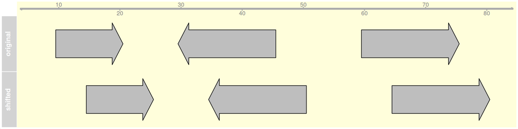

## `resize()` — fixed width, choose anchor

```r
plotGenomicTracks(list(
  original     = g,
  resize_start = resize(g, width = 10, fix = "start"),
  resize_end   = resize(g, width = 10, fix = "end")
))
```

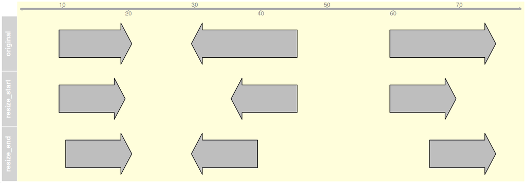

`fix` controls what stays put: `"start"`, `"end"`, or `"center"`.

## `narrow()` — trim from either end

```r
plotGenomicTracks(list(original = g,
                 narrow   = narrow(g, start = 2, end = -2)))
```

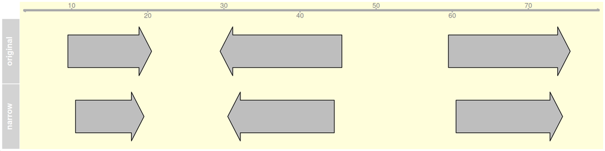

`start = 2` drops 1 bp from the start; `end = -2` drops 1 bp from the end.

## `flank()` — adjacent windows

Useful for promoters (5′ flank) and 3′ UTRs.

```r
plotGenomicTracks(list(
  original     = g,
  flank_5prime = flank(g, width = 5, start = TRUE),
  flank_3prime = flank(g, width = 5, start = FALSE)
))
```

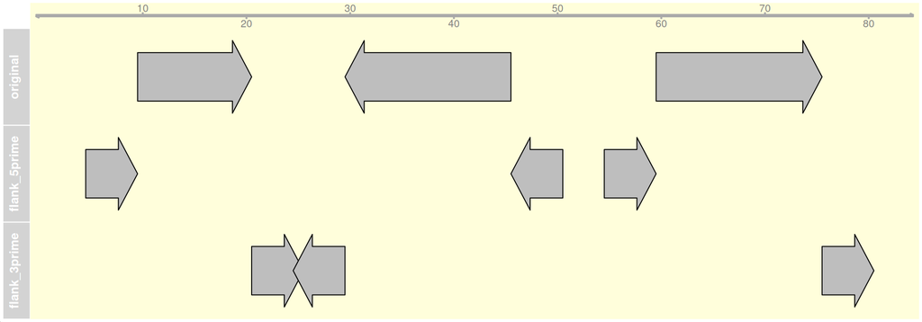

## `restrict()` — clip to a window

```r
plotGenomicTracks(list(original   = g,
                 restricted = restrict(g, start = 15, end = 50)))
```

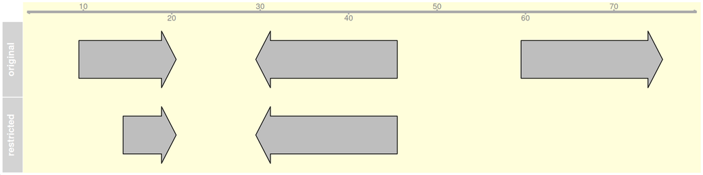

> 📝 **Task 3** — build a GRanges of 3 “genes” on chr1, then extract a **200 bp promoter** for each (use `flank()` with `start = TRUE`). Plot both tracks together.

# Part 6 — Finding overlaps

## Why overlap operations?

The single most common operation in genomics:

- *“Which of my peaks fall inside a gene?”*
- *“Which variants hit an exon?”*
- *“How many reads cover this region?”*

All use the same overlap machinery.

## `findOverlaps()`

```r
gr1 <- GRanges("chr1", IRanges(start = c(5, 80, 130), width = 20))
gr2 <- GRanges("chr1", IRanges(start = c(10, 100, 125), width = 15))
plotGenomicTracks(list(gr1 = gr1, gr2 = gr2))
```

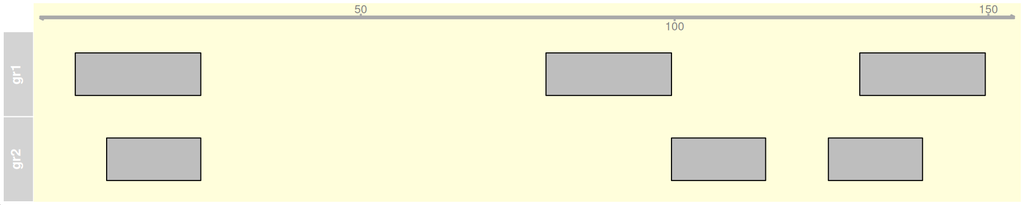

```r
hits <- findOverlaps(gr1, gr2)
hits
```

```
Hits object with 2 hits and 0 metadata columns:
      queryHits subjectHits
      <integer>   <integer>
  [1]         1           1
  [2]         3           3
  -------
  queryLength: 3 / subjectLength: 3
```

## Reading a `Hits` object

```r
queryHits(hits)     # indices into gr1
```

```
[1] 1 3
```

```r
subjectHits(hits)   # indices into gr2
```

```
[1] 1 3
```

Each pair `(queryHits[i], subjectHits[i])` is one overlapping pair.

## `countOverlaps()`

```r
countOverlaps(gr1, gr2)
```

```
[1] 1 0 1
```

For each range in `gr1`, how many ranges in `gr2` it overlaps.

## `subsetByOverlaps()`

```r
gr1_overlapping <- subsetByOverlaps(gr1, gr2)
plotGenomicTracks(list(gr1 = gr1, gr2 = gr2,
                 gr1_overlapping = gr1_overlapping))
```

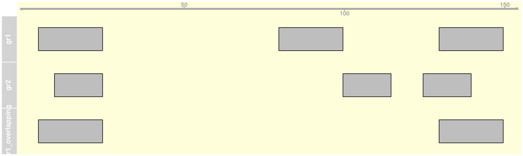

## `overlapsAny()`

```r
overlapsAny(gr1, gr2)
```

```
[1]  TRUE FALSE  TRUE
```

A logical vector — `TRUE` where the range has at least one overlap.

> 📝 **Task 4** — build two GRanges on chr1 of your choice and use `subsetByOverlaps()` to keep only the ranges of the first that overlap any range of the second. Plot input, reference, and result.

# Part 7 — Nearest-neighbor operations

## `nearest()` and `distance()`

```r
query   <- GRanges("chr1", IRanges(c(10, 25, 55), width = 5))
subject <- GRanges("chr1", IRanges(c(1, 18, 40, 70), width = 5))
plotGenomicTracks(list(query = query, subject = subject))
```

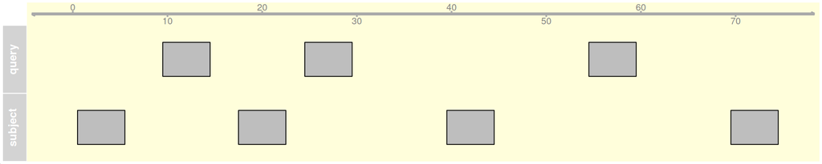

```r
nearest(query, subject)
```

```
[1] 2 2 3
```

```r
distance(query, subject[1:3])
```

```
[1]  4  2 10
```

## `precede()` and `follow()` — what they answer

Unlike `nearest()`, which can return a subject that *overlaps* the query, `precede` and `follow` always look **outside** the query and pick a **direction**.

- `precede(x, s)` — for each `x`, the index of the **first range in `s` that comes *after* `x` along the 5′ → 3′ direction**. *(In the printed gene-track sense: the next downstream feature.)*
- `follow(x, s)` — for each `x`, the index of the **last range in `s` that came *before* `x` along the 5′ → 3′ direction**. *(The previous upstream feature.)*

If no such range exists, the result is `NA`.

## Why “precede” feels backwards at first

Read the names from the **subject’s** point of view:

- *“Which range in `s` does `x` **precede**?”* → the one **after** `x`.
- *“Which range in `s` does `x` **follow**?”* → the one **before** `x`.

So `precede(x, s)` returns the **downstream** neighbor of `x`, and `follow(x, s)` returns the **upstream** neighbor of `x`. Many people remember it the other way around — keep this slide handy.

## A worked example

```r
q <- GRanges("chr1", IRanges(c(25), width = 5), strand = "+", id = "q")
s <- GRanges("chr1", IRanges(c(5, 15, 50, 70), width = 5),
             strand = "+", id = paste0("s", 1:4))
plotGenomicTracks(list(query = q, subject = s))
```

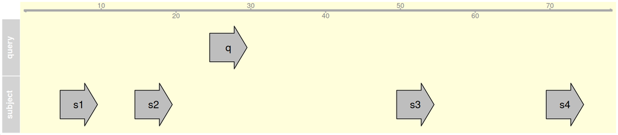

```r
precede(q, s)   # which subject comes AFTER q?  → s3 (index 3)
```

```
[1] 3
```

```r
follow(q, s)    # which subject came BEFORE q?  → s2 (index 2)
```

```
[1] 2
```

So `q` *precedes* `s[3]` and *follows* `s[2]`.

## Distance to the precede/follow neighbor

A common pattern: find the upstream/downstream neighbor and how far away it is.

```r
i_down <- precede(q, s)
i_up   <- follow(q, s)

distance(q, s[i_down])   # bp to next downstream feature
```

```
[1] 20
```

```r
distance(q, s[i_up])     # bp to previous upstream feature
```

```
[1] 5
```

This is exactly how you’d annotate “distance to next gene” for ChIP-seq peaks or variants.

## Why the strand matters

The 5′ → 3′ direction depends on **strand**, but plot positions go left-to-right. So on a `-`-strand gene, the *upstream* neighbor is on the **right** of the plot, and `follow()` returns it.

```r
q_minus <- GRanges("chr1", IRanges(25, width = 5), strand = "-", id = "q-")
s_plus  <- GRanges("chr1", IRanges(c(5, 50), width = 5),
                   strand = "+", id = c("s1", "s2"))
precede(q_minus, s_plus)   # NA: opposite strands
```

```
[1] NA
```

Mixed strands often return `NA` — see the table on the next slide.

## Strand effects on precede / follow

The strand of `x` and `subject` determines whether a comparison is even defined. Set `ignore.strand = TRUE` to disable this check.

| x | subject | orientation |
| --- | --- | --- |
| + | + | —> |
| + | - | NA |
| + | * | —> |
| - | - | <— |
| - | * | <— |
| * | + | —> |
| * | * | —> (only case where `*` arbitrarily means `+`) |

The single exception: when **both** `x` and `subject` are `*`, both are treated as `+`.

# Part 8 — Set operations on ranges

## Setup

```r
gr_a <- GRanges("chr1", IRanges(start = c(10, 20, 30), end = c(15, 25, 35)))
gr_b <- GRanges("chr1", IRanges(start = c(12, 22, 40), end = c(17, 27, 45)))
```

## `union()`

```r
plotGenomicTracks(list(gr_a = gr_a, gr_b = gr_b,
                 union = union(gr_a, gr_b)))
```

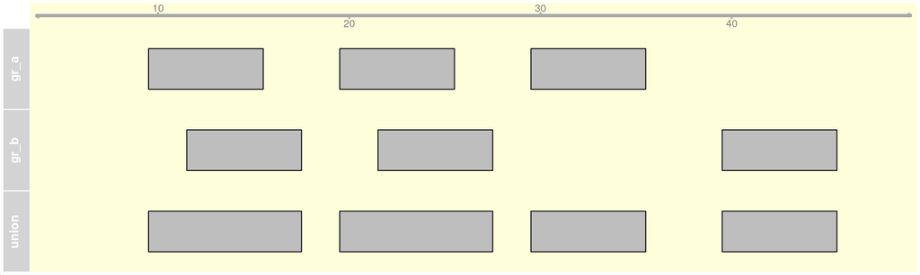

## `intersect()`

```r
plotGenomicTracks(list(gr_a = gr_a, gr_b = gr_b,
                 intersect = intersect(gr_a, gr_b)))
```

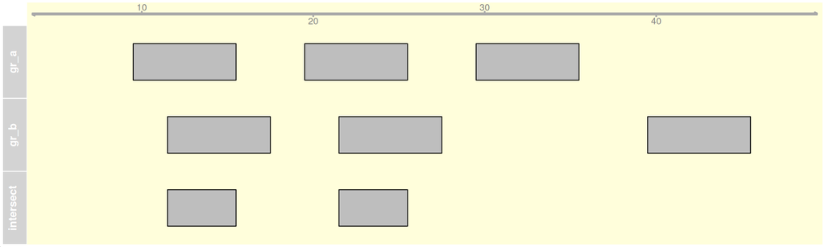

## `setdiff()`

```r
plotGenomicTracks(list(gr_a = gr_a, gr_b = gr_b,
                 setdiff = setdiff(gr_a, gr_b)))
```

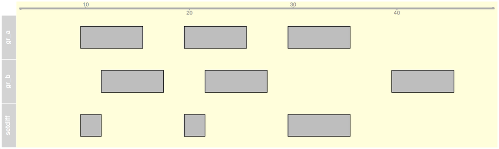

> 📝 **Task 5** — using `gr_a` and `gr_b` above, compute the **symmetric difference** (parts in either but not in both). Hint: `setdiff(union(...), intersect(...))`.

# Part 9 — GRangesList

## Why GRangesList?

Use a `GRangesList` when intervals come in groups:

- exons of a transcript,
- peaks per sample,
- binding sites per TF.

It is a list whose elements are all `GRanges`.

## Creating a GRangesList

```r
grl <- GRangesList(
  sample1 = GRanges(seqnames = c("chr1", "chr2"),
                    ranges   = IRanges(start = c(10, 20), end = c(20, 30))),
  sample2 = GRanges(seqnames = c("chr1", "chr3"),
                    ranges   = IRanges(start = c(15, 40), end = c(25, 50)))
)
grl
```

```
GRangesList object of length 2:
$sample1
GRanges object with 2 ranges and 0 metadata columns:
      seqnames    ranges strand
         <Rle> <IRanges>  <Rle>
  [1]     chr1     10-20      *
  [2]     chr2     20-30      *
  -------
  seqinfo: 3 sequences from an unspecified genome; no seqlengths

$sample2
GRanges object with 2 ranges and 0 metadata columns:
      seqnames    ranges strand
         <Rle> <IRanges>  <Rle>
  [1]     chr1     15-25      *
  [2]     chr3     40-50      *
  -------
  seqinfo: 3 sequences from an unspecified genome; no seqlengths
```

## Working with a GRangesList

```r
grl[[1]]              # first element
```

```
GRanges object with 2 ranges and 0 metadata columns:
      seqnames    ranges strand
         <Rle> <IRanges>  <Rle>
  [1]     chr1     10-20      *
  [2]     chr2     20-30      *
  -------
  seqinfo: 3 sequences from an unspecified genome; no seqlengths
```

```r
grl$sample2           # by name
```

```
GRanges object with 2 ranges and 0 metadata columns:
      seqnames    ranges strand
         <Rle> <IRanges>  <Rle>
  [1]     chr1     15-25      *
  [2]     chr3     40-50      *
  -------
  seqinfo: 3 sequences from an unspecified genome; no seqlengths
```

```r
elementNROWS(grl)     # length of each element
```

```
sample1 sample2
      2       2
```

```r
unlist(grl)           # flatten
```

```
GRanges object with 4 ranges and 0 metadata columns:
          seqnames    ranges strand
             <Rle> <IRanges>  <Rle>
  sample1     chr1     10-20      *
  sample1     chr2     20-30      *
  sample2     chr1     15-25      *
  sample2     chr3     40-50      *
  -------
  seqinfo: 3 sequences from an unspecified genome; no seqlengths
```

`endoapply(grl, shift, 5)` applies `shift()` to each element and returns a GRangesList of the same shape.

# Part 10 — Integration with Biostrings

## Sequences from coordinates

`getSeq()` extracts DNA from a `BSgenome` at the given GRanges coordinates.

```r
library(BSgenome.Hsapiens.UCSC.hg38)

genes <- GRanges(
  seqnames = c("chr1", "chr2"),
  ranges   = IRanges(start = c(10000, 20000), end = c(10500, 20500)),
  strand   = c("+", "-"),
  gene_id  = c("gene1", "gene2")
)

gene_seqs <- getSeq(BSgenome.Hsapiens.UCSC.hg38, genes)
names(gene_seqs) <- genes$gene_id
gene_seqs
letterFrequency(gene_seqs, "GC", as.prob = TRUE)
```

The BSgenome package is large (~1 GB) — skip if not installed.